# IRT without the normality assumption

```r
library(IRTest)
```

```r
library(ggplot2)
library(gridExtra)
```

# 0. Introduction

- **IRTest** is a useful tool for $\mathcal{\color{red}{IRT}}$ (item response theory) parameter $\mathcal{\color{red}{est}}$imation, especially when the violation of normality assumption on latent distribution is suspected.
- **IRTest** deals with uni-dimensional latent variable.
- For missing values, **IRTest** adopts full information maximum likelihood (FIML) approach.
- In **IRTest**, including the conventional usage of Gaussian distribution, several methods are available for estimation of latent distribution:
  - empirical histogram method,
  - two-component Gaussian mixture distribution,
  - Davidian curve,
  - kernel density estimation,
  - log-linear smoothing.

## Installation

The CRAN version of **IRTest** can be installed on R-console with:

```
install.packages("IRTest")
```

For the development version, it can be installed on R-console with:

```
devtools::install_github("SeewooLi/IRTest")
```

## Functions

Followings are the functions of **IRTest**.

- `IRTest_Dich` is the estimation function when all items are *dichotomously* scored.
- `IRTest_Poly` is the estimation function when all items are *polytomously* scored.
- `IRTest_Cont` is the estimation function when all items are *continuously* scored.
- `IRTest_Mix` is the estimation function for *a mixed-format test*, a test comprising both dichotomous item(s) and polytomous item(s).
- `factor_score` estimates factor scores of examinees.
- `coef_se` returns standard errors of item parameter estimates.
- `best_model` selects the best model using an evaluation criterion.
- `item_fit` tests the statistical fit of all items individually.
- `inform_f_item` calculates the information value(s) of an item.
- `inform_f_test` calculates the information value(s) of a test.
- `plot_item` draws item response function(s) of an item.
- `reliability` calculates marginal reliability coefficient of IRT.
- `latent_distribution` returns evaluated PDF value(s) of an estimated latent distribution.
- `DataGeneration` generates several objects that can be useful for computer simulation studies. Among these are simulated item parameters, ability parameters and the corresponding item-response data.
- `dist2` is a probability density function of two-component Gaussian mixture distribution.
- `original_par_2GM` converts re-parameterized parameters of two-component Gaussian mixture distribution into original parameters.
- `cat_clps` recommends category collapsing based on item parameters (or, equivalently, item response functions).
- `recategorize` implements the category collapsing.
- `adaptive_test` estimates ability parameter(s) which can be utilized for computer adaptive testing (CAT).
- For S3 methods, `anova`, `coef`, `logLik`, `plot`, `print`, and `summary` are available.

# 1. Dichotomous items

- **Preparing data**

The function `DataGeneration` can be used in a preparation step. This function returns a set of artificial data and the true parameters underlying the data.

```r
Alldata <- DataGeneration(model_D = 2,
                          N=1000,
                          nitem_D = 15,
                          latent_dist = "2NM",
                          d = 1.664,
                          sd_ratio = 2,
                          prob = 0.3)

data <- Alldata$data_D
theta <- Alldata$theta
colnames(data) <- paste0("item", 1:15)
```

- **Analysis** (parameter estimation)

```r
Mod1 <- IRTest_Dich(data = data,
                    model = 2,
                    latent_dist = "LLS",
                    h=4)
```

- **Results**

```r
### Summary
summary(Mod1)
```

```
#> Convergence:
#> Successfully converged below the threshold of 1e-04 on 45th iterations.
#>
#> Model Fit:
#>  log-likeli   -7662.596
#>    deviance   15325.19
#>         AIC   15393.19
#>         BIC   15560.06
#>          HQ   15456.61
#>
#> The Number of Parameters:
#>        item   30
#>        dist   4
#>       total   34
#>
#> The Number of Items:  15
#>
#> The Estimated Latent Distribution:
#> method - LLS
#> ----------------------------------------
#>
#>
#>
#>
#>           . .             . @ @ .
#>       . @ @ @ @ @ . . @ @ @ @ @ @
#>       @ @ @ @ @ @ @ @ @ @ @ @ @ @ @
#>     @ @ @ @ @ @ @ @ @ @ @ @ @ @ @ @ .
#>     @ @ @ @ @ @ @ @ @ @ @ @ @ @ @ @ @
#>   @ @ @ @ @ @ @ @ @ @ @ @ @ @ @ @ @ @ .
#> +---------+---------+---------+---------+
#> -2        -1        0         1         2
```

```r
### Log-likelihood
logLik(Mod1)
```

```
#> [1] -7662.596
```

```r
### The estimated item parameters
coef(Mod1)
```

```
#>                a            b c
#> item1  0.9836460  1.329453969 0
#> item2  2.2856088 -0.687404304 0
#> item3  1.1690163 -0.215261793 0
#> item4  0.8122027  0.003225493 0
#> item5  1.6372745 -1.189646841 0
#> item6  1.2152175  0.121197281 0
#> item7  1.5656469  0.360962838 0
#> item8  2.5239584  1.182579688 0
#> item9  2.3468154  0.148729175 0
#> item10 1.0642603 -0.894474941 0
#> item11 2.2604198  1.540381124 0
#> item12 1.6180704 -0.263752903 0
#> item13 1.5673423  0.147437141 0
#> item14 1.8951604 -1.107805291 0
#> item15 1.5037221 -0.179279324 0
```

```r
### Standard errors of the item parameter estimates
coef_se(Mod1)
```

```
#>                 a          b  c
#> item1  0.09101569 0.11521202 NA
#> item2  0.14467868 0.04196280 NA
#> item3  0.08298967 0.06304486 NA
#> item4  0.07293209 0.08380740 NA
#> item5  0.12363246 0.06673970 NA
#> item6  0.08463917 0.06036465 NA
#> item7  0.10018749 0.05100714 NA
#> item8  0.20149922 0.04677130 NA
#> item9  0.13758907 0.03887234 NA
#> item10 0.08506922 0.08394286 NA
#> item11 0.21591435 0.07116718 NA
#> item12 0.10017918 0.04990388 NA
#> item13 0.09811743 0.05014991 NA
#> item14 0.13792130 0.05618842 NA
#> item15 0.09501085 0.05207528 NA
```

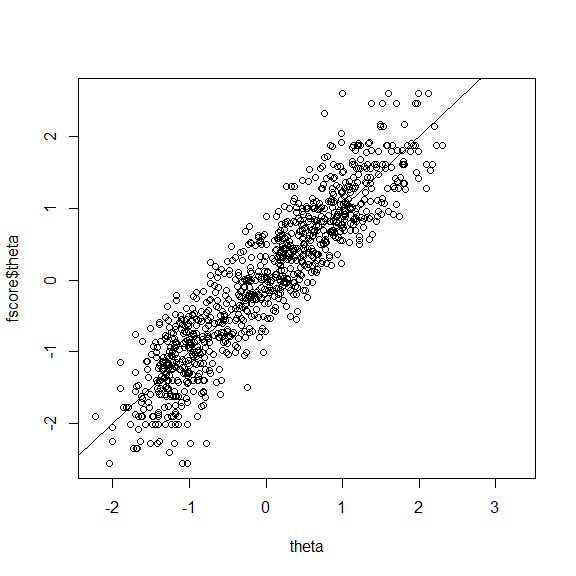

```r
### The estimated ability parameters
fscore <- factor_score(Mod1, ability_method = "MLE")
plot(theta, fscore$theta)
abline(b=1, a=0)
```

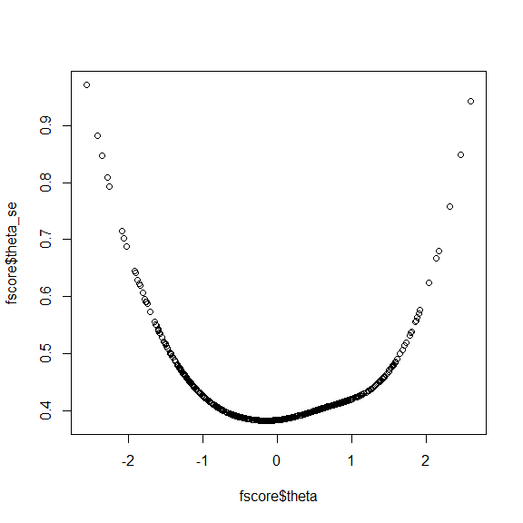

```r
### Standard errors of ability parameter estimates
plot(fscore$theta, fscore$theta_se)
```

- The result of latent distribution estimation

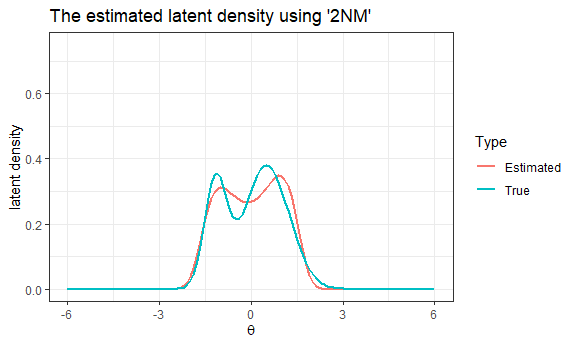

```r
plot(Mod1, mapping = aes(colour="Estimated"), linewidth = 1) +
  lims(y = c(0, .75))+
  geom_line(
    mapping=aes(
      x=seq(-6,6,length=121),
      y=dist2(seq(-6,6,length=121), prob = .3, d = 1.664, sd_ratio = 2),
      colour="True"),
    linewidth = 1)+
  labs(title="The estimated latent density using '2NM'", colour= "Type")+
  theme_bw()
```

- Item response function

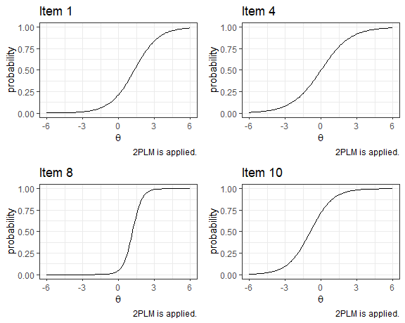

```r
p1 <- plot_item(Mod1,1)
p2 <- plot_item(Mod1,4)
p3 <- plot_item(Mod1,8)
p4 <- plot_item(Mod1,10)
grid.arrange(p1, p2, p3, p4, ncol=2, nrow=2)
```

- **Item fit**

```r
item_fit(Mod1)
```

```
#>            stat df p.value
#> item1  11.96160  7  0.1018
#> item2  30.48842  7  0.0001
#> item3  12.97163  7  0.0728
#> item4  11.04379  7  0.1367
#> item5  16.82329  7  0.0186
#> item6  10.73184  7  0.1508
#> item7  15.91906  7  0.0259
#> item8  35.92517  7  0.0000
#> item9  19.94981  7  0.0057
#> item10 16.02558  7  0.0249
#> item11 24.35734  7  0.0010
#> item12 18.96927  7  0.0083
#> item13 18.77397  7  0.0089
#> item14 17.79823  7  0.0129
#> item15 13.57151  7  0.0593
```

- Reliability

```r
reliability(Mod1)
```

```
#> $summed.score.scale
#> $summed.score.scale$test
#> test reliability
#>        0.8550052
#>
#> $summed.score.scale$item
#>     item1     item2     item3     item4     item5     item6     item7     item8
#> 0.1412426 0.4667651 0.2394863 0.1366549 0.2791276 0.2522459 0.3378448 0.3719255
#>     item9    item10    item11    item12    item13    item14    item15
#> 0.5174065 0.1884686 0.2572114 0.3619343 0.3482940 0.3337077 0.3339890
#>
#>
#> $theta.scale
#> test reliability
#>        0.8404062
```

- Posterior distributions for the examinees

Each examinee’s posterior distribution is identified in the E-step of the estimation algorithm (i.e., EM algorithm). Posterior distributions can be found in `Mod1$Pk`.

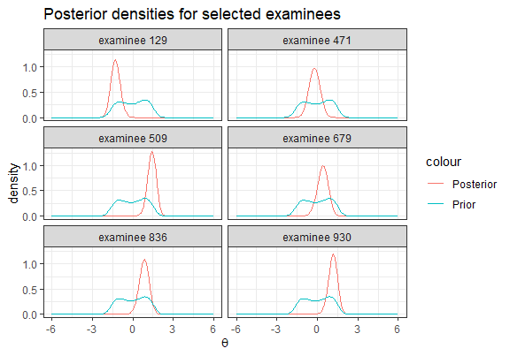

```r
set.seed(1)
selected_examinees <- sample(1:1000,6)
post_sample <-
  data.frame(
    X = rep(seq(-6,6, length.out=121),6),
    prior = rep(Mod1$Ak/(Mod1$quad[2]-Mod1$quad[1]), 6),
    posterior = 10*c(t(Mod1$Pk[selected_examinees,])),
    ID = rep(paste("examinee", selected_examinees), each=121)
    )

ggplot(data=post_sample, mapping=aes(x=X))+
  geom_line(mapping=aes(y=posterior, group=ID, color='Posterior'))+
  geom_line(mapping=aes(y=prior, group=ID, color='Prior'))+
  labs(title="Posterior densities for selected examinees", x=expression(theta), y='density')+
  facet_wrap(~ID, ncol=2)+
  theme_bw()
```

- Test information function

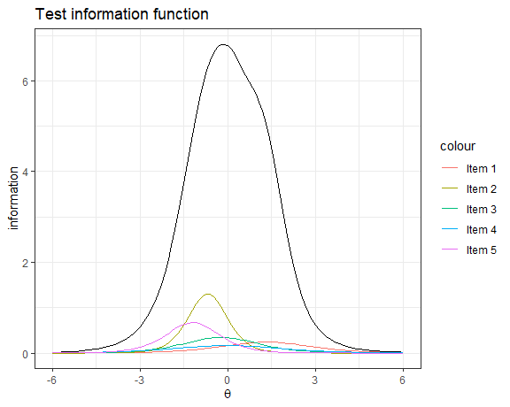

```r
ggplot()+
  stat_function(
    fun = inform_f_test,
    args = list(Mod1)
  )+
  stat_function(
    fun=inform_f_item,
    args = list(Mod1, 1),
    mapping = aes(color="Item 1")
  )+
  stat_function(
    fun=inform_f_item,
    args = list(Mod1, 2),
    mapping = aes(color="Item 2")
  )+
  stat_function(
    fun=inform_f_item,
    args = list(Mod1, 3),
    mapping = aes(color="Item 3")
  )+
  stat_function(
    fun=inform_f_item,
    args = list(Mod1, 4),
    mapping = aes(color="Item 4")
  )+
  stat_function(
    fun=inform_f_item,
    args = list(Mod1, 5),
    mapping = aes(color="Item 5")
  )+
  lims(x=c(-6,6))+
  labs(title="Test information function", x=expression(theta), y='information')+
  theme_bw()
```

# 2. Polytomous items

- **Preparing data**

```r
Alldata <- DataGeneration(model_P = "GRM",
                          categ = rep(c(3,7), each = 7),
                          N=1000,
                          nitem_P = 14,
                          latent_dist = "2NM",
                          d = 1.664,
                          sd_ratio = 2,
                          prob = 0.3)

data <- Alldata$data_P
theta <- Alldata$theta
colnames(data) <- paste0("item", 1:14)
```

- **Analysis** (parameter estimation)

```r
Mod1 <- IRTest_Poly(data = data,
                    model = "GRM",
                    latent_dist = "KDE")
```

- **Results**

```r
### Summary
summary(Mod1)
```

```
#> Convergence:
#> Successfully converged below the threshold of 1e-04 on 30th iterations.
#>
#> Model Fit:
#>  log-likeli   -11867.05
#>    deviance   23734.1
#>         AIC   23870.1
#>         BIC   24203.83
#>          HQ   23996.94
#>
#> The Number of Parameters:
#>        item   67
#>        dist   1
#>       total   68
#>
#> The Number of Items:  14
#>
#> The Estimated Latent Distribution:
#> method - KDE
#> ----------------------------------------
#>
#>
#>
#>                         .
#>           . @ @ @ @ @ @ @ @ .
#>         . @ @ @ @ @ @ @ @ @ @ @
#>       . @ @ @ @ @ @ @ @ @ @ @ @ @
#>       @ @ @ @ @ @ @ @ @ @ @ @ @ @ .
#>     @ @ @ @ @ @ @ @ @ @ @ @ @ @ @ @ @
#>   @ @ @ @ @ @ @ @ @ @ @ @ @ @ @ @ @ @ @ .
#> +---------+---------+---------+---------+
#> -2        -1        0         1         2
```

```r
### Log-likelihood
logLik(Mod1)
```

```
#> [1] -11867.05
```

```r
### The estimated item parameters
coef(Mod1)
```

```
#>                a         b_1         b_2         b_3        b_4        b_5
#> item1  1.7988485  0.05401123  0.09398055          NA         NA         NA
#> item2  2.0043067 -0.49151815  0.88695638          NA         NA         NA
#> item3  0.8364980 -3.18445026 -2.38926385          NA         NA         NA
#> item4  0.9158959 -1.89519730 -1.11485493          NA         NA         NA
#> item5  2.0544736  1.21477800  1.86998613          NA         NA         NA
#> item6  2.2364252 -0.86509330 -0.76042262          NA         NA         NA
#> item7  2.5872397  1.62484703  1.71397551          NA         NA         NA
#> item8  2.4386132 -1.31540968 -1.08825163 -0.93434347 -0.5066227 -0.4651258
#> item9  2.0036899  2.34331711  2.53589908  3.16351996  3.4377154         NA
#> item10 2.0581555 -0.76315133 -0.52287005 -0.31563388 -0.2768377  0.3010941
#> item11 1.3617716 -2.04232380 -1.52909952 -1.12964290 -0.6051969 -0.5874733
#> item12 1.0856304 -0.85140919 -0.44231746  0.05233322  0.1786312  0.2497041
#> item13 0.9913453 -0.28218061  0.24473148  0.44191560  0.6480541  0.9343655
#> item14 2.1127859 -0.17731670  0.28797638  0.29842595  0.3696553  0.5204740
#>               b_6
#> item1          NA
#> item2          NA
#> item3          NA
#> item4          NA
#> item5          NA
#> item6          NA
#> item7          NA
#> item8  -0.3070251
#> item9          NA
#> item10  0.4299311
#> item11         NA
#> item12  1.0180891
#> item13  1.4177310
#> item14  0.6766842
```

```r
### Standard errors of the item parameter estimates
coef_se(Mod1)
```

```
#>                 a        b_1        b_2        b_3        b_4        b_5
#> item1  0.11073114 0.04486570 0.04497786         NA         NA         NA
#> item2  0.09858216 0.04347355 0.04920590         NA         NA         NA
#> item3  0.10469227 0.35380581 0.25735550         NA         NA         NA
#> item4  0.08207781 0.15972272 0.10612244         NA         NA         NA
#> item5  0.14580557 0.05639000 0.08780972         NA         NA         NA
#> item6  0.14441077 0.04469104 0.04257786         NA         NA         NA
#> item7  0.23648116 0.06790597 0.07362468         NA         NA         NA
#> item8  0.12154940 0.05036114 0.04419347 0.04113448 0.03667716 0.03650767
#> item9  0.24603699 0.15352565 0.17566410 0.26414336 0.31559599         NA
#> item10 0.09610058 0.04531634 0.04187806 0.04018262 0.03998476 0.04105944
#> item11 0.08788259 0.11824810 0.08970124 0.07247437 0.05788855 0.05758618
#> item12 0.06830391 0.07887899 0.06808232 0.06406234 0.06478591 0.06550493
#> item13 0.06828836 0.07211232 0.07048538 0.07355080 0.07864225 0.08840144
#> item14 0.10387197 0.04007432 0.03968341 0.03974503 0.04025363 0.04184932
#>               b_6
#> item1          NA
#> item2          NA
#> item3          NA
#> item4          NA
#> item5          NA
#> item6          NA
#> item7          NA
#> item8  0.03634449
#> item9          NA
#> item10 0.04246064
#> item11         NA
#> item12 0.08534119
#> item13 0.11032712
#> item14 0.04428654
```

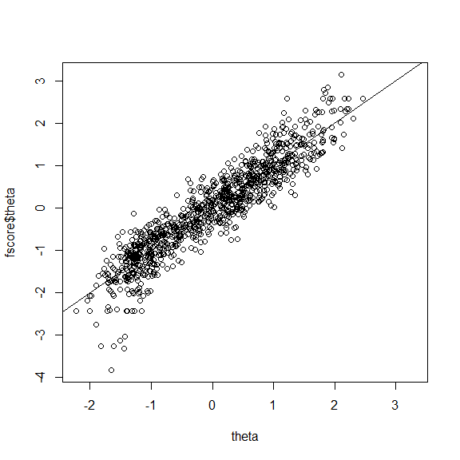

```r
### The estimated ability parameters
fscore <- factor_score(Mod1, ability_method = "MLE")
plot(theta, fscore$theta)
abline(b=1, a=0)
```

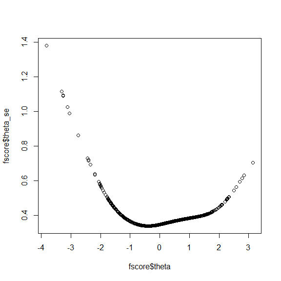

```r
### Standard errors of ability parameter estimates
plot(fscore$theta, fscore$theta_se)
```

- The result of latent distribution estimation

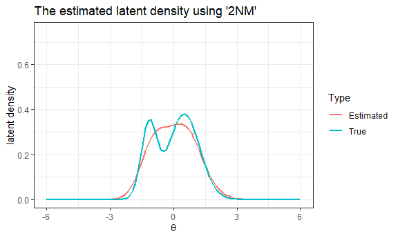

```r
plot(Mod1, mapping = aes(colour="Estimated"), linewidth = 1) +
  stat_function(
    fun = dist2,
    args = list(prob = .3, d = 1.664, sd_ratio = 2),
    mapping = aes(colour = "True"),
    linewidth = 1) +
  lims(y = c(0, .75)) +
  labs(title="The estimated latent density using '2NM'", colour= "Type")+
  theme_bw()
```

- Item response function

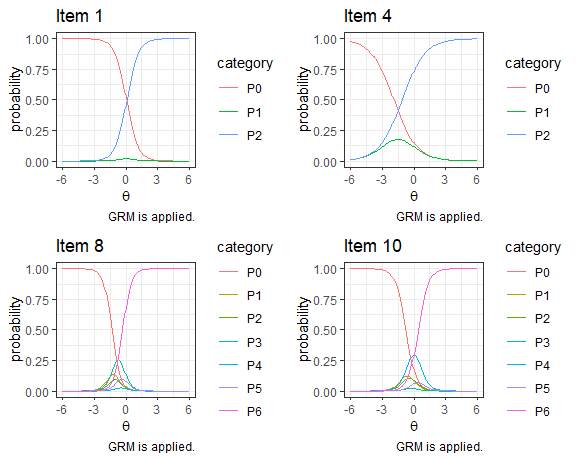

```r
p1 <- plot_item(Mod1,1)
p2 <- plot_item(Mod1,4)
p3 <- plot_item(Mod1,8)
p4 <- plot_item(Mod1,10)
grid.arrange(p1, p2, p3, p4, ncol=2, nrow=2)
```

- **Item fit**

```r
item_fit(Mod1)
```

```
#>            stat df p.value
#> item1  14.35691 15  0.4987
#> item2  18.95744 15  0.2157
#> item3  13.47278 15  0.5658
#> item4  18.21689 15  0.2514
#> item5  22.98208 15  0.0845
#> item6  23.89178 15  0.0670
#> item7  11.01423 15  0.7516
#> item8  51.99993 47  0.2855
#> item9  20.19194 31  0.9316
#> item10 47.39453 47  0.4565
#> item11 38.71699 39  0.4827
#> item12 44.63516 47  0.5710
#> item13 51.69728 47  0.2955
#> item14 45.54566 47  0.5329
```

- Reliability

```r
reliability(Mod1)
```

```
#> $summed.score.scale
#> $summed.score.scale$test
#> test reliability
#>        0.8423786
#>
#> $summed.score.scale$item
#>      item1      item2      item3      item4      item5      item6      item7
#> 0.38547011 0.49427544 0.07314142 0.13961946 0.36918780 0.42828060 0.36663417
#>      item8      item9     item10     item11     item12     item13     item14
#> 0.54822704 0.17552217 0.51886901 0.28678300 0.24874696 0.21063051 0.49749765
#>
#>
#> $theta.scale
#> test reliability
#>        0.8699627
```

- Posterior distributions for the examinees

Each examinee’s posterior distribution is identified in the E-step of the estimation algorithm (i.e., EM algorithm). Posterior distributions can be found in `Mod1$Pk`.

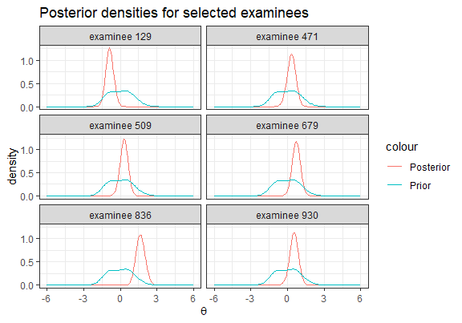

```r
set.seed(1)
selected_examinees <- sample(1:1000,6)
post_sample <-
  data.frame(
    X = rep(seq(-6,6, length.out=121),6),
    prior = rep(Mod1$Ak/(Mod1$quad[2]-Mod1$quad[1]), 6),
    posterior = 10*c(t(Mod1$Pk[selected_examinees,])),
    ID = rep(paste("examinee", selected_examinees), each=121)
    )

ggplot(data=post_sample, mapping=aes(x=X))+
  geom_line(mapping=aes(y=posterior, group=ID, color='Posterior'))+
  geom_line(mapping=aes(y=prior, group=ID, color='Prior'))+
  labs(title="Posterior densities for selected examinees", x=expression(theta), y='density')+
  facet_wrap(~ID, ncol=2)+
  theme_bw()
```

- Test information function

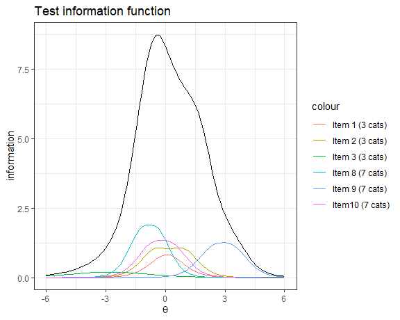

```r
ggplot()+
  stat_function(
    fun = inform_f_test,
    args = list(Mod1)
  )+
  stat_function(
    fun=inform_f_item,
    args = list(Mod1, 1),
    mapping = aes(color="Item 1 (3 cats)")
  )+
  stat_function(
    fun=inform_f_item,
    args = list(Mod1, 2),
    mapping = aes(color="Item 2 (3 cats)")
  )+
  stat_function(
    fun=inform_f_item,
    args = list(Mod1, 3),
    mapping = aes(color="Item 3 (3 cats)")
  )+
  stat_function(
    fun=inform_f_item,
    args = list(Mod1, 8),
    mapping = aes(color="Item 8 (7 cats)")
  )+
  stat_function(
    fun=inform_f_item,
    args = list(Mod1, 9),
    mapping = aes(color="Item 9 (7 cats)")
  )+
  stat_function(
    fun=inform_f_item,
    args = list(Mod1, 10, "p"),
    mapping = aes(color="Item10 (7 cats)")
  )+
  lims(x=c(-6,6))+
  labs(title="Test information function", x=expression(theta), y='information')+
  theme_bw()
```

# 3. Continuous items

- **Statistical details of the continuous IRT**

**Beta distribution (click)**

$$\begin{align}
f(x) &= \frac{1}{Beta(\alpha, \beta)}x^{\alpha-1}(1-x)^{(\beta-1)}
\\
&=
\frac{\Gamma(\alpha+\beta)}{\Gamma(\alpha)\Gamma(\beta)}x^{\alpha-1}(1-x)^{(\beta-1)}
\end{align}$$

$E(x)=\frac{\alpha}{\alpha+\beta}$ and $Var(x)=\frac{\alpha\beta}{(\alpha+\beta)^2(\alpha+\beta=1)}$ If we reparameterize $\mu=\frac{\alpha}{\alpha+\beta}$ and $\nu=\alpha+\beta$,

$$f(x) =
\frac{\Gamma(\nu)}{\Gamma(\mu\nu)\Gamma(\nu(1-\mu))}x^{\mu\nu-1}(1-x)^{(\nu(1-\mu)-1)}$$
No Jacobian transformation required since $\mu$ and $\nu$ are parameters of the $f(x)$, not variables.

**Useful equations (click)**

$\psi(\bullet)$ and $\psi_1(\bullet)$ denote for digamma and trigamma functions, respectively.

$$\begin{align}
E[\log{x}] &= \int_{0}^{1}{\log{x}f(x) \,dx} \\
&= \int_{0}^{1}{\log{x} \frac{1}{Beta(\alpha,
\beta)}x^{\alpha-1}(1-x)^{(\beta-1)} \,dx} \\
&= \frac{1}{Beta(\alpha, \beta)} \int_{0}^{1}{\log{(x)}
x^{\alpha-1}(1-x)^{(\beta-1)} \,dx} \\
&= \frac{1}{Beta(\alpha, \beta)} \int_{0}^{1}{\frac{\partial
x^{\alpha-1}(1-x)^{(\beta-1)}}{\partial \alpha} \,dx} \\
&= \frac{1}{Beta(\alpha, \beta)} \frac{\partial}{\partial
\alpha}\int_{0}^{1}{ x^{\alpha-1}(1-x)^{(\beta-1)} \,dx} \\
&= \frac{1}{Beta(\alpha, \beta)} \frac{\partial Beta(\alpha,
\beta)}{\partial \alpha} \\
&= \frac{\partial \log{[Beta(\alpha, \beta)]}}{\partial \alpha} \\
&= \frac{\partial \log{[\Gamma(\alpha)]}}{\partial \alpha} -
\frac{\partial \log{[\Gamma(\alpha + \beta)]}}{\partial \alpha} \\
&= \psi(\alpha) - \psi(\alpha+\beta)
\end{align}$$

Similarly, $E[\log{(1-x)}]=\psi(\beta) - \psi(\alpha+\beta)$.

Furthermore, using $\frac{\partial Beta(\alpha,\beta)}{\partial \alpha} = Beta(\alpha,\beta)\left(\psi(\alpha)-\psi(\alpha+\beta)\right)$ and $\frac{\partial^2 Beta(\alpha,\beta)}{\partial \alpha^2} = Beta(\alpha,\beta)\left(\psi(\alpha)-\psi(\alpha+\beta)\right)^2 + Beta(\alpha,\beta)\left(\psi_1(\alpha)-\psi_1(\alpha+\beta)\right)$,

$$\begin{align}
E\left[(\log{x})^2\right] &= \frac{1}{Beta(\alpha, \beta)}
\frac{\partial^2 Beta(\alpha, \beta)}{\partial \alpha^2} \\
&= \left(\psi(\alpha)-\psi(\alpha+\beta)\right)^2 +
\left(\psi_1(\alpha)-\psi_1(\alpha+\beta)\right)
\end{align}$$

This leads to,

$$\begin{align}
Var\left[\log{x}\right] &= E\left[(\log{x})^2\right] -
E\left[\log{x}\right]^2 \\
&=\psi_1(\alpha)-\psi_1(\alpha+\beta)
\end{align}$$

**Continuous IRT (click)**

- Expected item response

$$\mu = \frac{e^{a(\theta -b)}}{1+e^{a(\theta -b)}} \\
\frac{\partial \mu}{\partial \theta} = a\mu(1-\mu) \\
\frac{\partial \mu}{\partial a} = (\theta - b)\mu(1-\mu) \\
\frac{\partial \mu}{\partial b} = -a\mu(1-\mu) \\
\frac{\partial \mu}{\partial \nu} = 0$$

- Probability of a response

$$f(x)=P(x|\, \theta, a, b, \nu) =
\frac{\Gamma(\nu)}{\Gamma(\mu\nu)\Gamma(\nu(1-\mu))} x^{\mu\nu-1}
(1-x)^{\nu(1-\mu)-1} \\$$

- Gradient

$$\log{f} =
\log{\Gamma(\nu)}-\log{\Gamma(\mu\nu)}-\log{\Gamma(\nu(1-\mu))} +
(\mu\nu-1)\log{x} + (\nu(1-\mu)-1) \log{(1-x)}$$

$$\frac{\partial \log{f}}{\partial \theta} =
a\nu\mu(1-\mu)\left[-\psi{(\mu\nu)}+\psi{(\nu(1-\mu))}+
\log{\left(\frac{x}{1-x}\right)}\right]$$

- Information

$$E\left[ \left(\frac{\partial \log{f}}{\partial \theta}\right)^2 \right]
=
(a\nu\mu(1-\mu))^2\left[E\left[
\log{\left(\frac{x}{1-x}\right)^2}\right]
-2 \left(\psi{(\mu\nu)}-\psi{(\nu(1-\mu))}\right )E\left[
\log{\left(\frac{x}{1-x}\right)}\right]
+\left(\psi{(\mu\nu)}-\psi{(\nu(1-\mu))}\right )^2
\right]$$

$$\begin{align}
E\left[ \log{\left(\frac{x}{1-x}\right)^2}\right]
&= E\left[ \log{\left(x\right)^2}\right]
-2 E\left[ \log{\left(x\right)}\log{\left(1-x\right)}\right]
+ E\left[ \log{\left(1-x\right)^2}\right] \\
&= Var\left[ \log{\left(x\right)}\right]+E\left[
\log{\left(x\right)}\right]^2 \\
&\qquad -2 Cov\left[
\log{\left(x\right)}\log{\left(1-x\right)}\right]-2E\left[
\log{\left(x\right)}\right]E\left[ \log{\left(1-x\right)}\right] \\
&\qquad + Var\left[ \log{\left(1-x\right)}\right]+E\left[
\log{\left(1-x\right)}\right]^2 \\
&= \psi_{1}(\alpha)-\psi_{1}(\alpha+\beta) +E\left[
\log{\left(x\right)}\right]^2 \\
&\qquad +2 \psi_{1}(\alpha+\beta)-2E\left[
\log{\left(x\right)}\right]E\left[ \log{\left(1-x\right)}\right] \\
&\qquad + \psi_{1}(\beta)-\psi_{1}(\alpha+\beta)+E\left[
\log{\left(1-x\right)}\right]^2 \\
&= \psi_{1}(\alpha)-\psi_{1}(\alpha+\beta) +\left[
\psi(\alpha)-\psi(\alpha+\beta)\right]^2 \\
&\qquad +2 \psi_{1}(\alpha+\beta)-2
\left(\psi(\alpha)-\psi(\alpha+\beta)\right)\left(\psi(\beta)-\psi(\alpha+\beta)\right) \\
&\qquad +
\psi_{1}(\beta)-\psi_{1}(\alpha+\beta)+\left[\psi(\beta)-\psi(\alpha+\beta)\right]^2
\\
&= \psi_{1}(\alpha) +\psi_{1}(\beta)
+\left[\psi(\alpha)-\psi(\beta)\right]^2
\end{align}$$

$$\begin{align}
E\left[\left(\frac{\partial \log{f}}{\partial \theta}\right)^2 \right]
& =
(a\nu\mu(1-\mu))^2\left[E\left[
\log{\left(\frac{x}{1-x}\right)^2}\right]
-2 \left(\psi{(\mu\nu)}-\psi{(\nu(1-\mu))}\right )E\left[
\log{\left(\frac{x}{1-x}\right)}\right]
+\left(\psi{(\mu\nu)}-\psi{(\nu(1-\mu))}\right )^2
\right] \\
&= (a\nu\mu(1-\mu))^2\left[\psi_{1}(\alpha) +\psi_{1}(\beta)
+\left[\psi(\alpha)-\psi(\beta)\right]^2
-2 \left(\psi{(\alpha)}-\psi{(\beta)}\right
)\left(\psi{(\alpha)}-\psi{(\beta)}\right )
+\left(\psi{(\alpha)}-\psi{(\beta)}\right )^2
\right] \\
&= (a\nu\mu(1-\mu))^2\left[\psi_{1}(\alpha) +\psi_{1}(\beta)
\right] \\
\end{align}$$

$$I(\theta) = E\left[\left(\frac{\partial \log{f}}{\partial
\theta}\right)^2 \right] = (a\nu\mu(1-\mu))^2\left[\psi_{1}(\alpha)
+\psi_{1}(\beta)\right]$$

- Log-likelihood in the M-step of the MML-EM procedure

Marginal log-likelihood of an item can be expressed as follows:

$$\ell = \sum_{j} \sum_{q}\gamma_{jq}\log{L_{jq}},$$

where $\gamma_{jq}=E\left[\Pr\left(\theta_j \in \theta_{q}^{*}\right)\right]$ is the expected probability of respondent $j$’s ability ($\theta_j$) belonging to the $\theta_{q}^{*}$ of the quadrature scheme and is calculated at the E-step of the MML-EM procedure, and $L_{jq}$ is the likelihood of respondent $j$’s response at $\theta_{q}^{*}$ for the item of current interest.

- First derivative of the likelihood

$$\frac{\partial \ell}{\partial a} = \sum_{q}
\left(\theta_{q}-b\right)\nu\mu_{q}\left(1-\mu_{q}\right)\left[
S_{1q}-S_{2q}-f_q\left[ \psi(\mu_{q}\nu)-\psi(\nu(1-\mu_{q})) \right]
\right] \\
\frac{\partial \ell}{\partial b} =
-a\sum_{q}\nu\mu_{q}\left(1-\mu_{q}\right)\left[
S_{1q}-S_{2q}-f_q\left[ \psi(\mu_{q}\nu)-\psi(\nu(1-\mu_{q})) \right]
\right] \\
\frac{\partial \ell}{\partial \nu} = N\psi(\nu) +\sum_{q}\left[
\mu_{q}(S_{1q}-f_q\psi(\mu_{q}\nu)) +
(1-\mu_{q})(S_{2q}-f_q\psi(\nu(1-\mu_{q})))
\right]$$

where $S_{1q} = \sum_{j}{\gamma_{jq}\log{x_j}}$ and $S_{2q} = \sum_{j}{\gamma_{jq}\log{(1-x_j)}}$. Since $E_q[S_{1q}]=f_q\left[\psi(\mu_{q}\nu))-\psi(\nu)\right]$ and $E_q[S_{2q}]=f_q\left[\psi(\nu(1-\mu_{q})))-\psi(\nu)\right]$, the expected values of the first derivatives are 0.

To keep $\nu$ positive, let $\nu = \exp{\xi}$; $\frac{\partial\nu}{\partial\xi}=\exp{\xi}=\nu$.

$$\frac{\partial \ell}{\partial \xi} = N\nu\psi(\nu) +\nu\sum_{q}\left[
\mu_{q}(S_{1q}-f_q\psi(\mu_{q}\nu)) +
(1-\mu_{q})(S_{2q}-f_q\psi(\nu(1-\mu_{q})))
\right]$$

- Second derivative of the likelihood

$$E\left( \frac{\partial^2\ell}{\partial a^2}\right) = -\sum_{q}
\left\{\left(\theta_{q}-b\right)\nu\mu_{q}\left(1-\mu_{q}\right)\right\}^{2}f_{q}\left[
\psi_{1}(\mu_{q}\nu)+\psi_{1}(\nu(1-\mu_{q})) \right] \\
E\left(\frac{\partial^2\ell}{\partial a \partial b}\right) = a\sum_{q}
\left(\theta_{q}-b\right)\left\{\nu\mu_{q}\left(1-\mu_{q}\right)\right\}^{2}f_{q}\left[
\psi_{1}(\mu_{q}\nu)+\psi_{1}(\nu(1-\mu_{q})) \right] \\
E\left(\frac{\partial^2\ell}{\partial a \partial \nu}\right) = -\sum_{q}
\left(\theta_{q}-b\right)\nu\mu_{q}\left(1-\mu_{q}\right)f_q\left[
\mu_{q}\psi_{1}(\mu_{q}\nu)-(1-\mu_{q})\psi_{1}(\nu(1-\mu_{q})) \right]
\\
E\left(\frac{\partial^2\ell}{\partial b^2}\right) = -a^{2}\sum_{q}
\left\{\nu\mu_{q}\left(1-\mu_{q}\right)\right\}^{2}f_{q}\left[
\psi_{1}(\mu_{q}\nu)+\psi_{1}(\nu(1-\mu_{q})) \right] \\
E\left(\frac{\partial^2\ell}{\partial b \partial \nu}\right) = a\sum_{q}
\nu\mu_{q}\left(1-\mu_{q}\right)f_q\left[
\mu_{q}\psi_{1}(\mu_{q}\nu)-(1-\mu_{q})\psi_{1}(\nu(1-\mu_{q})) \right]
\\
E\left(\frac{\partial^2\ell}{\partial \nu^2}\right) = N\psi_{1}(\nu) -
\sum_{q}f_q\left[
\mu_{q}^{2}\psi_{1}(\mu_{q}\nu)+(1-\mu_{q})^{2}\psi_{1}(\nu(1-\mu_{q}))
\right]$$

If we use $\xi$ instead of $\nu$,

$$E\left(\frac{\partial^2\ell}{\partial a \partial \xi}\right) = -\sum_{q}
\left(\theta_{q}-b\right)\nu^{2}\mu_{q}\left(1-\mu_{q}\right)f_q\left[
\mu_{q}\psi_{1}(\mu_{q}\nu)-(1-\mu_{q})\psi_{1}(\nu(1-\mu_{q})) \right]
\\
E\left(\frac{\partial^2\ell}{\partial b \partial \xi}\right) = a\sum_{q}
\nu^{2}\mu_{q}\left(1-\mu_{q}\right)f_q\left[
\mu_{q}\psi_{1}(\mu_{q}\nu)-(1-\mu_{q})\psi_{1}(\nu(1-\mu_{q})) \right]
\\
E\left(\frac{\partial^2\ell}{\partial \xi^2}\right) =
N\nu^{2}\psi_{1}(\nu) - \nu^{2}\sum_{q}f_q\left[
\mu_{q}^{2}\psi_{1}(\mu_{q}\nu)+(1-\mu_{q})^{2}\psi_{1}(\nu(1-\mu_{q}))
\right]$$

- **Preparing data**

The function `DataGeneration` can be used in a preparation step. This function returns a set of artificial data and the true parameters underlying the data.

```r
Alldata <- DataGeneration(N=1000,
                          nitem_C = 8,
                          latent_dist = "2NM",
                          a_l = .3,
                          a_u = .7,
                          d = 1.664,
                          sd_ratio = 2,
                          prob = 0.3)

data <- Alldata$data_C
theta <- Alldata$theta
colnames(data) <- paste0("item", 1:8)
```

- **Analysis** (parameter estimation)

```r
Mod1 <- IRTest_Cont(data = data,
                    latent_dist = "KDE")
```

- **Results**

```r
### Summary
summary(Mod1)
```

```
#> Convergence:
#> Successfully converged below the threshold of 1e-04 on 31st iterations.
#>
#> Model Fit:
#>  log-likeli   2825.34
#>    deviance   -5650.679
#>         AIC   -5600.679
#>         BIC   -5477.985
#>          HQ   -5554.047
#>
#> The Number of Parameters:
#>        item   24
#>        dist   1
#>       total   25
#>
#> The Number of Items:  8
#>
#> The Estimated Latent Distribution:
#> method - KDE
#> ----------------------------------------
#>
#>
#>
#>               . . . . .
#>             @ @ @ @ @ @ @ .
#>           @ @ @ @ @ @ @ @ @ @
#>         @ @ @ @ @ @ @ @ @ @ @ @ .
#>       @ @ @ @ @ @ @ @ @ @ @ @ @ @ .
#>     @ @ @ @ @ @ @ @ @ @ @ @ @ @ @ @ @
#>   @ @ @ @ @ @ @ @ @ @ @ @ @ @ @ @ @ @ @ .
#> +---------+---------+---------+---------+
#> -2        -1        0         1         2
```

```r
### Log-likelihood
logLik(Mod1)
```

```
#> [1] 2825.34
```

```r
### The estimated item parameters
coef(Mod1)
```

```
#>               a          b        nu
#> item1 0.5585796  1.2924295  8.470660
#> item2 0.3406646 -0.6946243  5.423534
#> item3 0.4047930 -0.1765202 11.279811
#> item4 0.4839899 -0.1150749  9.674475
#> item5 0.3109872 -1.1347071  9.879757
#> item6 0.4666123  0.1573268  9.476279
#> item7 0.6554120  0.3054941  7.947572
#> item8 0.3897490  1.3419728  4.469948
```

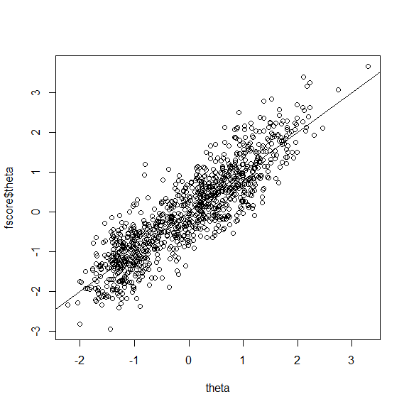

```r
### The estimated ability parameters
fscore <- factor_score(Mod1, ability_method = "WLE")
plot(theta, fscore$theta)
abline(b=1, a=0)
```

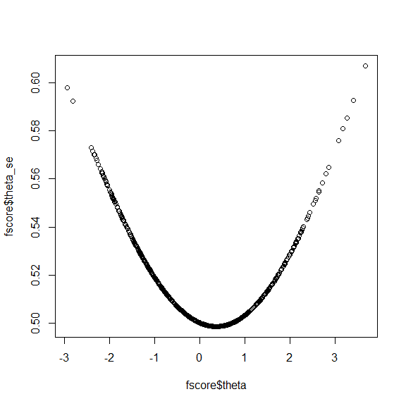

```r
### Standard errors of ability parameter estimates
plot(fscore$theta, fscore$theta_se)
```

- The result of latent distribution estimation

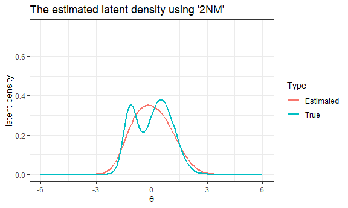

```r
plot(Mod1, mapping = aes(colour="Estimated"), linewidth = 1) +
  lims(y = c(0, .75))+
  geom_line(
    mapping=aes(
      x=seq(-6,6,length=121),
      y=dist2(seq(-6,6,length=121), prob = .3, d = 1.664, sd_ratio = 2),
      colour="True"),
    linewidth = 1)+
  labs(title="The estimated latent density using '2NM'", colour= "Type")+
  theme_bw()
```

- Item response function

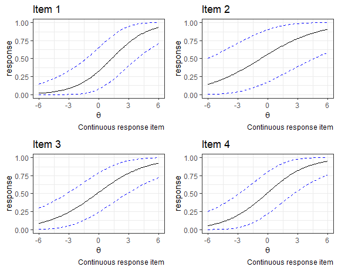

```r
p1 <- plot_item(Mod1,1)
p2 <- plot_item(Mod1,2)
p3 <- plot_item(Mod1,3)
p4 <- plot_item(Mod1,4)
grid.arrange(p1, p2, p3, p4, ncol=2, nrow=2)
```

- Reliability

```r
reliability(Mod1)
```

```
#> $summed.score.scale
#> $summed.score.scale$test
#> NULL
#>
#> $summed.score.scale$item
#> NULL
#>
#>
#> $theta.scale
#> test reliability
#>        0.7923939
```

- Posterior distributions for the examinees

Each examinee’s posterior distribution is identified in the E-step of the estimation algorithm (i.e., EM algorithm). Posterior distributions can be found in `Mod1$Pk`.

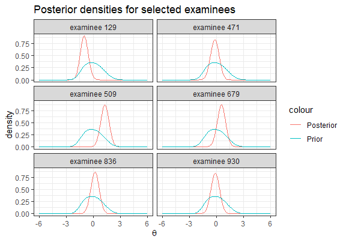

```r
set.seed(1)
selected_examinees <- sample(1:1000,6)
post_sample <-
  data.frame(
    X = rep(seq(-6,6, length.out=121),6),
    prior = rep(Mod1$Ak/(Mod1$quad[2]-Mod1$quad[1]), 6),
    posterior = 10*c(t(Mod1$Pk[selected_examinees,])),
    ID = rep(paste("examinee", selected_examinees), each=121)
    )

ggplot(data=post_sample, mapping=aes(x=X))+
  geom_line(mapping=aes(y=posterior, group=ID, color='Posterior'))+
  geom_line(mapping=aes(y=prior, group=ID, color='Prior'))+
  labs(title="Posterior densities for selected examinees", x=expression(theta), y='density')+
  facet_wrap(~ID, ncol=2)+
  theme_bw()
```

- Test information function

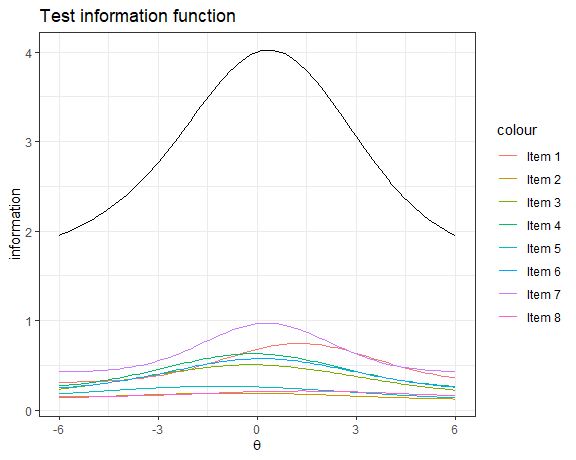

```r
ggplot()+
  stat_function(
    fun = inform_f_test,
    args = list(Mod1)
  )+
  stat_function(
    fun=inform_f_item,
    args = list(Mod1, 1),
    mapping = aes(color="Item 1")
  )+
  stat_function(
    fun=inform_f_item,
    args = list(Mod1, 2),
    mapping = aes(color="Item 2")
  )+
  stat_function(
    fun=inform_f_item,
    args = list(Mod1, 3),
    mapping = aes(color="Item 3")
  )+
  stat_function(
    fun=inform_f_item,
    args = list(Mod1, 4),
    mapping = aes(color="Item 4")
  )+
  stat_function(
    fun=inform_f_item,
    args = list(Mod1, 5),
    mapping = aes(color="Item 5")
  )+
  stat_function(
    fun=inform_f_item,
    args = list(Mod1, 6),
    mapping = aes(color="Item 6")
  )+
  stat_function(
    fun=inform_f_item,
    args = list(Mod1, 7),
    mapping = aes(color="Item 7")
  )+
  stat_function(
    fun=inform_f_item,
    args = list(Mod1, 8),
    mapping = aes(color="Item 8")
  )+
  lims(x=c(-6,6))+
  labs(title="Test information function", x=expression(theta), y='information')+
  theme_bw()
```

# 4. Mixed-format test

- **Preparing data**

As in the cases of dichotomous and polytomous items, the function `DataGeneration` can be used in the preparation step. This function returns artificial data and some useful objects for analysis (i.e., `theta`, `data_D`, `item_D`, `data_P`, & `item_P`).

```r
Alldata <- DataGeneration(model_D = 2,
                          model_P = "GRM",
                          N=1000,
                          nitem_D = 10,
                          nitem_P = 5,
                          latent_dist = "2NM",
                          d = 1.664,
                          sd_ratio = 1,
                          prob = 0.5)

DataD <- Alldata$data_D
DataP <- Alldata$data_P
theta <- Alldata$theta
colnames(DataD) <- paste0("item", 1:10)
colnames(DataP) <- paste0("item", 1:5)
```

- **Analysis** (parameter estimation)

```r
Mod1 <- IRTest_Mix(data_D = DataD,
                   data_P = DataP,
                   model_D = "2PL",
                   model_P = "GRM",
                   latent_dist = "KDE")
```

- **Results**

```r
### Summary
summary(Mod1)
```

```
#> Convergence:
#> Successfully converged below the threshold of 1e-04 on 43rd iterations.
#>
#> Model Fit:
#>  log-likeli   -2832829
#>    deviance   5665658
#>         AIC   5665750
#>         BIC   5665976
#>          HQ   5665836
#>
#> The Number of Parameters:
#>        item   45
#>        dist   1
#>       total   46
#>
#> The Number of Items:
#> dichotomous   10
#> polyotomous   5
#>
#> The Estimated Latent Distribution:
#> method - KDE
#> ----------------------------------------
#>
#>
#>
#>
#>           . @ @ @ . . . . . .
#>         . @ @ @ @ @ @ @ @ @ @ @ .
#>       . @ @ @ @ @ @ @ @ @ @ @ @ @
#>       @ @ @ @ @ @ @ @ @ @ @ @ @ @ @
#>     @ @ @ @ @ @ @ @ @ @ @ @ @ @ @ @ @
#>   @ @ @ @ @ @ @ @ @ @ @ @ @ @ @ @ @ @ @ .
#> +---------+---------+---------+---------+
#> -2        -1        0         1         2
```

```r
### Log-likelihood
logLik(Mod1)
```

```
#> [1] -2832829
```

```r
### The estimated item parameters
coef(Mod1)
```

```
#> $Dichotomous
#>                a          b c
#> item1  0.7891202  1.2625485 0
#> item2  1.2499965 -0.6495540 0
#> item3  1.8413035 -0.2451646 0
#> item4  1.3725921 -0.2179645 0
#> item5  2.3290534 -1.2186082 0
#> item6  1.2979304  0.1663487 0
#> item7  1.1538293  0.3064596 0
#> item8  1.0723793  1.2980064 0
#> item9  2.3294905  0.1395925 0
#> item10 2.6566442 -0.9381758 0
#>
#> $Polytomous
#>               a        b_1        b_2         b_3         b_4
#> item1 1.7960156 -1.3772222 -0.4490053 -0.07115149 -0.02269190
#> item2 2.6132883 -1.2435968 -0.5217730 -0.07802599  0.64758495
#> item3 0.9616471 -0.9965864 -0.9735484 -0.39246415  0.01840465
#> item4 1.2488737 -1.1075645 -0.1732780  0.11281676  0.76505236
#> item5 1.8737454 -1.8756187 -1.3588250 -0.31849429 -0.25998056
```

```r
### Standard errors of the item parameter estimates
coef_se(Mod1)
```

```
#> $Dichotomous
#>                 a          b  c
#> item1  0.07934206 0.13525483 NA
#> item2  0.09168355 0.06571107 NA
#> item3  0.11346457 0.04489424 NA
#> item4  0.09237972 0.05525207 NA
#> item5  0.18356284 0.05217865 NA
#> item6  0.08899798 0.05764454 NA
#> item7  0.08430875 0.06452792 NA
#> item8  0.09291723 0.10476652 NA
#> item9  0.13860432 0.03870397 NA
#> item10 0.18921268 0.04016531 NA
#>
#> $Polytomous
#>                a        b_1        b_2        b_3        b_4
#> item1 0.09208419 0.06469868 0.04524516 0.04436168 0.04457621
#> item2 0.10609490 0.04453496 0.03528593 0.03442853 0.03772448
#> item3 0.07092293 0.09430095 0.09328353 0.07468456 0.07197619
#> item4 0.07098634 0.07674239 0.05756408 0.05754074 0.06819791
#> item5 0.09945962 0.08399190 0.06140695 0.04355022 0.04347977
```

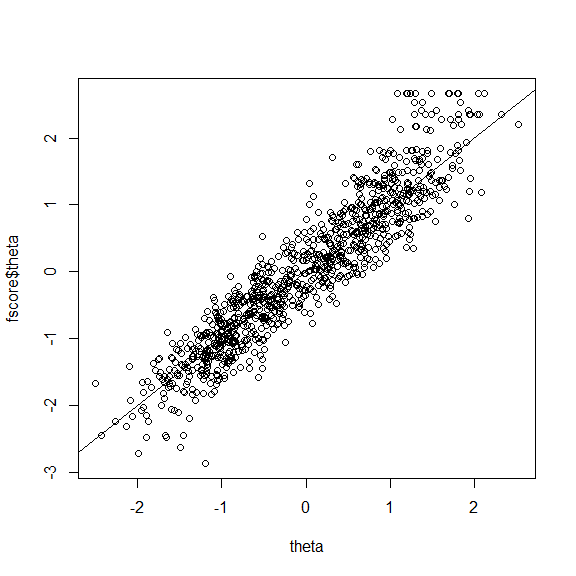

```r
### The estimated ability parameters
fscore <- factor_score(Mod1, ability_method = "MLE")
plot(theta, fscore$theta)
abline(b=1, a=0)
```

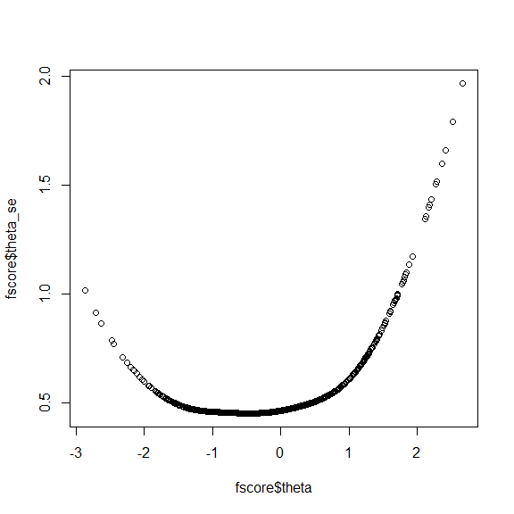

```r
### Standard errors of ability parameter estimates
plot(fscore$theta, fscore$theta_se)
```

- The result of latent distribution estimation

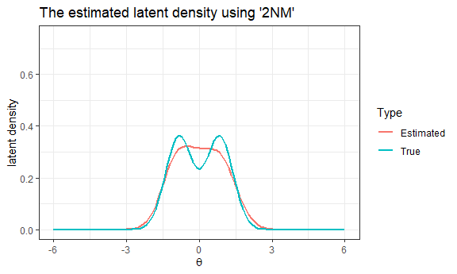

```r
plot(Mod1, mapping = aes(colour="Estimated"), linewidth = 1) +
  stat_function(
    fun = dist2,
    args = list(prob = .5, d = 1.664, sd_ratio = 1),
    mapping = aes(colour = "True"),
    linewidth = 1) +
  lims(y = c(0, .75)) +
  labs(title="The estimated latent density using '2NM'", colour= "Type")+
  theme_bw()
```

- Item response function

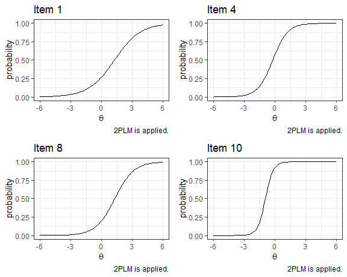

```r
p1 <- plot_item(Mod1,1, type="d")
p2 <- plot_item(Mod1,4, type="d")
p3 <- plot_item(Mod1,8, type="d")
p4 <- plot_item(Mod1,10, type="d")
grid.arrange(p1, p2, p3, p4, ncol=2, nrow=2)
```

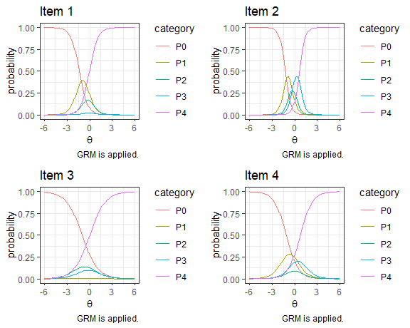

```r
p1 <- plot_item(Mod1,1, type="p")
p2 <- plot_item(Mod1,2, type="p")
p3 <- plot_item(Mod1,3, type="p")
p4 <- plot_item(Mod1,4, type="p")
grid.arrange(p1, p2, p3, p4, ncol=2, nrow=2)
```

- **Item fit**

```r
item_fit(Mod1)
```

```
#> $Dichotomous
#>             stat df p.value
#> item1   7.789464  7  0.3515
#> item2   4.200670  7  0.7564
#> item3   9.025276  7  0.2508
#> item4  10.302423  7  0.1721
#> item5   8.308049  7  0.3062
#> item6  16.019905  7  0.0249
#> item7  29.980665  7  0.0001
#> item8  19.251959  7  0.0074
#> item9  13.524989  7  0.0603
#> item10  9.733639  7  0.2042
#>
#> $Polytomous
#>           stat df p.value
#> item1 31.18450 31  0.4569
#> item2 49.30446 31  0.0196
#> item3 43.98313 31  0.0612
#> item4 43.01137 31  0.0741
#> item5 46.51346 31  0.0363
```

- Reliability

```r
reliability(Mod1)
```

```
#> $summed.score.scale
#> $summed.score.scale$test
#> test reliability
#>        0.8521683
#>
#> $summed.score.scale$item
#>   item1_D   item2_D   item3_D   item4_D   item5_D   item6_D   item7_D   item8_D
#> 0.1105553 0.2355015 0.3930709 0.2830257 0.3620972 0.2659396 0.2252809 0.1663649
#>   item9_D  item10_D   item1_P   item2_P   item3_P   item4_P   item5_P
#> 0.4929316 0.4546042 0.4444386 0.6534434 0.1920587 0.3118755 0.4410517
#>
#>
#> $theta.scale
#> test reliability
#>        0.8529496
```

- Posterior distributions for the examinees

Each examinee’s posterior distribution is identified in the E-step of the estimation algorithm (i.e., EM algorithm). Posterior distributions can be found in `Mod1$Pk`.

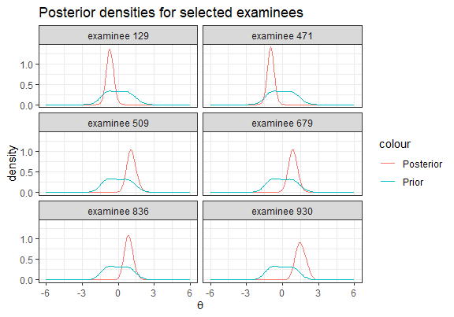

```r
set.seed(1)
selected_examinees <- sample(1:1000,6)
post_sample <-
  data.frame(
    X = rep(seq(-6,6, length.out=121),6),
    prior = rep(Mod1$Ak/(Mod1$quad[2]-Mod1$quad[1]), 6),
    posterior = 10*c(t(Mod1$Pk[selected_examinees,])),
    ID = rep(paste("examinee", selected_examinees), each=121)
    )

ggplot(data=post_sample, mapping=aes(x=X))+
  geom_line(mapping=aes(y=posterior, group=ID, color='Posterior'))+
  geom_line(mapping=aes(y=prior, group=ID, color='Prior'))+
  labs(title="Posterior densities for selected examinees", x=expression(theta), y='density')+
  facet_wrap(~ID, ncol=2)+
  theme_bw()
```

- Test information function

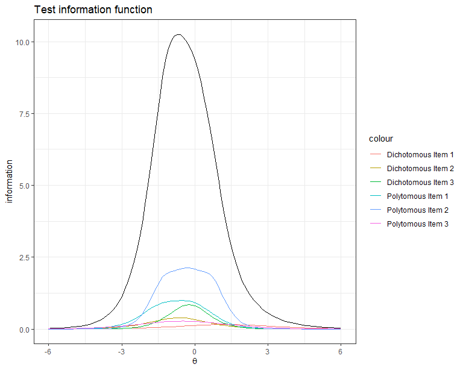

```r
ggplot()+
  stat_function(
    fun = inform_f_test,
    args = list(Mod1)
  )+
  stat_function(
    fun=inform_f_item,
    args = list(Mod1, 1, "d"),
    mapping = aes(color="Dichotomous Item 1")
  )+
  stat_function(
    fun=inform_f_item,
    args = list(Mod1, 2, "d"),
    mapping = aes(color="Dichotomous Item 2")
  )+
  stat_function(
    fun=inform_f_item,
    args = list(Mod1, 3, "d"),
    mapping = aes(color="Dichotomous Item 3")
  )+
  stat_function(
    fun=inform_f_item,
    args = list(Mod1, 1, "p"),
    mapping = aes(color="Polytomous Item 1")
  )+
  stat_function(
    fun=inform_f_item,
    args = list(Mod1, 2, "p"),
    mapping = aes(color="Polytomous Item 2")
  )+
  stat_function(
    fun=inform_f_item,
    args = list(Mod1, 3, "p"),
    mapping = aes(color="Polytomous Item 3")
  )+
  lims(x=c(-6,6))+
  labs(title="Test information function", x=expression(theta), y='information')+
  theme_bw()
```

# 5. Model comparison

- **Data generation and model fitting**

```r
data <- DataGeneration(N=1000,
                       nitem_D = 10,
                       latent_dist = "2NM",
                       d = 1.664,
                       sd_ratio = 2,
                       prob = 0.3)$data_D
```

```r
model_fits <- list()
model_fits[[1]] <- IRTest_Dich(data)
model_fits[[2]] <- IRTest_Dich(data, latent_dist = "EHM")
model_fits[[3]] <- IRTest_Dich(data, latent_dist = "2NM")
model_fits[[4]] <- IRTest_Dich(data, latent_dist = "KDE")
for(i in 1:10){
  model_fits[[i+4]] <- IRTest_Dich(data, latent_dist = "DC", h = i)
}

names(model_fits) <- c("Normal", "EHM", "2NM", "KDM", paste0("DC", 1:10))
```

- **The best Davidian-curve model**

```r
do.call(what = "anova", args = model_fits[5:14])
```

```
#> Result of model comparison
#>
#>         logLik deviance      AIC      BIC       HQ n_pars           chi p_value
#> DC1  -5390.940 10781.88 10823.88 10926.94 10863.05     21            NA      NA
#> DC2  -5390.940 10781.88 10825.88 10933.85 10866.92     22 -9.369668e-05  1.0000
#> DC3  -5390.843 10781.69 10827.69 10940.56 10870.59     23  1.931828e-01  0.6603
#> DC4  -5390.940 10781.88 10829.88 10947.67 10874.65     24 -1.930907e-01  1.0000
#> DC5  -5388.329 10776.66 10826.66 10949.35 10873.29     25  5.221515e+00  0.0223
#> DC6  -5382.972 10765.94 10817.94 10945.55 10866.44     26  1.071369e+01  0.0011
#> DC7  -5388.634 10777.27 10831.27 10963.78 10881.63     27 -1.132386e+01  1.0000
#> DC8  -5400.197 10800.39 10856.39 10993.81 10908.62     28 -2.312559e+01  1.0000
#> DC9  -5386.136 10772.27 10830.27 10972.60 10884.37     29  2.812130e+01  0.0000
#> DC10 -5392.918 10785.84 10845.84 10993.07 10901.80     30 -1.356425e+01  1.0000
```

```r
do.call(what = "best_model", args = model_fits[5:14])
```

```
#> The best model: DC1
#>
#>            HQ
#> DC1  10863.05
#> DC2  10866.92
#> DC3  10870.59
#> DC4  10874.65
#> DC5  10873.29
#> DC6  10866.44
#> DC7  10881.63
#> DC8  10908.62
#> DC9  10884.37
#> DC10 10901.80
```

- **The best model overall**

```r
do.call(what = "best_model", args = c(model_fits[c(1:4,5)], criterion ="AIC"))
```

```
#> The best model: 2NM
#>
#>             AIC
#> Normal 10821.88
#> EHM    11030.50
#> 2NM    10801.16
#> KDM    10807.41
#> DC1    10823.88
```